# Lab 10 – Statistical Techniques Pt. 1

The next two labs focus on statistical techniques that data scientists should know: Principal Component Analysis, Partitional Clustering, and Hierarchical Clustering.

**Note:** You may see many math terms unfamiliar to you if you have not previously taken Linear Algebra or Probability Theory. This is to show you a real application, and perhaps motivate you to take these classes.

## Preamble

### Packages and Datasets

```r
# load the following packages
# install.packages("factoextra")
# install.packages("psych")
# install.packages("corrplot")
# install.packages("cluster")
library(cluster)
library(psych)
library(factoextra)
library(ggplot2)
library(dplyr)
library(corrplot)
```

### Principal Component Analysis (PCA)

#### Introduction

So far we’ve relied on data visualization as our primary method for identifying trends, but this has its limitations, especially when the number of variables is large.

Consider data consisting of $n$ measurements (observations) of $p$ variables, represented by the matrix $\mathbf{X}$:

$$\mathbf{X} =
\begin{pmatrix}
x_{1,1} & x_{1,2} & \cdots & x_{1,p} \\
x_{2,1} & x_{2,2} & \cdots & x_{2,p} \\
\vdots & \vdots & \ddots & \vdots \\
x_{n,1} & x_{n,2} & \cdots & x_{n,p}
\end{pmatrix}$$
Our goal in this lab is to find relationships in the columns of $\mathbf{X}$ (ie: find patterns across variables) using **principal component analysis** (PCA). In doing so, we hope to come up with interpretable, low-dimensional representations of the key trends contained in our data.

$~$

#### Dimension Reduction

The main idea behind PCA for dimension reduction is as follows:

1. Each observation (data-point) has a location in a $p$-dimensional space, but not all of these dimensions are *equally interesting*.
2. PCA derives a set of new dimensions ordered by *variation*. Dimensions without much variation (few differences across observations) aren’t very interesting and can be discarded.

Consider the following example:

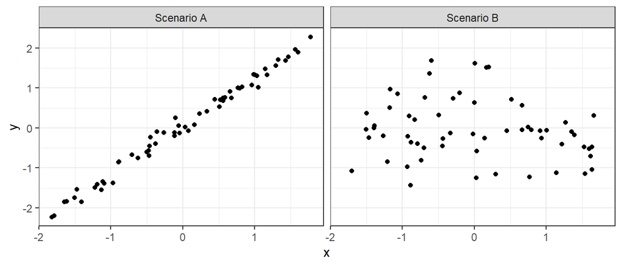

In Scenario A, the variables X and Y are *redundant*

- If you know an observation’s X-value, you essentially know it’s Y-value too.
- One dimension (ie: a line) to capture most of the variation in the variables X and Y.

In scenario B, where isn’t much redundancy in X and Y

- Knowing an observation’s X-value tells you very little about its Y-value.
- One dimension *cannot* effectively capture the variation in these two variables, we need a two-dimensional plane.

The next figure (below) shows the *first principal component* (red) and *second principal component* (blue) for each scenario:

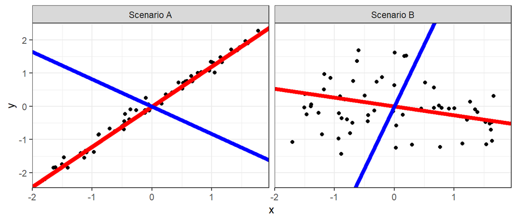

The first (red) component is constructed to contain the maximum amount of variation in the data, and the second (blue) component is orthogonal to the first.

We can now define the location of each data-point using a coordinate scale in these new dimensions (ie: $\{PC_1, PC_2\}$ rather than $\{X, Y\}$). In scenario A, the $PC_2$ coordinates have so little variation that we don’t lose much by ignoring them and only considering the $PC_1$ coordinate of an observation (reducing two dimensions down to just one dimension)

$~$

#### Mathematical Details

Principal components can be expressed by linear combinations of the original variables:

$$PC_1 = \phi_{11} X_1 + \phi_{21} X_2 +
\ldots + \phi_{p1} X_p \\
PC_2 = \phi_{12} X_1 + \phi_{22} X_2 + \ldots + \phi_{p2} X_p \\
\ldots$$

The coefficients, $\phi_{11}, \phi_{21}, \ldots$, are called **loadings**. They describe the contribution of a variable to a principal component. The matrix containing these loadings is sometimes called the **rotation matrix**.

If you plug-in the values of $X_1, \ldots, X_p$ for an observation and multiply by the loadings the resulting value of $PC_1$ is called a **score**. This is the location of that observation in the $PC_1$ dimension (ie: position on the $PC_1$ axis).

The first step in PCA is to **standardize** $\mathbf{X}$, which prevents variables with larger values from dominating. We want the difference between 1m and 10 m (a value of 9) to be treated the same as that between 1000mm and 10000mm (a value of 9000).

After standardization, we’ll consider the **covariance matrix** $\mathbf{C}= \tfrac{1}{n-1}\mathbf{X}^T\mathbf{X}$. Using techniques from linear algebra, we can factor this matrix:

$$\mathbf{C} =
\mathbf{V}\mathbf{L}\mathbf{V}^T$$

- $\mathbf{V}$ is a matrix of **eigenvectors**, while $\mathbf{L}$ is a diagonal matrix of **eigenvalues**
- The *columns* of $\mathbf{V}$ contain the *loadings* for each principal component
- The elements of $\mathbf{L}$ relate to the “variance explained” (importance) of each principal component

$~$

$~$

## Lab Part 1: PCA

### Example

The `USArrests` data set contains four variables for each of the 50 states.

```r
data("USArrests")
head(USArrests)
```

|  | Murder | Assault | UrbanPop | Rape |
| --- | --- | --- | --- | --- |
| Alabama | 13.2 | 236 | 58 | 21.2 |
| Alaska | 10.0 | 263 | 48 | 44.5 |
| Arizona | 8.1 | 294 | 80 | 31.0 |
| Arkansas | 8.8 | 190 | 50 | 19.5 |
| California | 9.0 | 276 | 91 | 40.6 |
| Colorado | 7.9 | 204 | 78 | 38.7 |

If we create a *scatterplot* matrix (using `pairs()`), we see signs of redundancy, particularly between “Assault” and “Murder”:

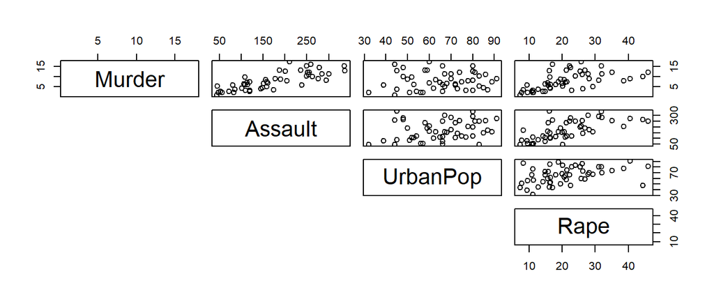

```r
## Step 1 - check for signs of redundancy
pairs(USArrests, lower.panel = NULL)
```

**Question 1:** Explain what I mean by redundancy in terms of two quantitative variables.

To perform PCA, we first must standardize the data (using `scale()`):

```r
## Step 2 - standardize the numeric variables
USArrests_std <- scale(USArrests)
```

**Question 2:** Explain what benefits we may gain by standardizing a variable.

We then use the `prcomp()` function to find the principal components:

```r
## Step 3 - perform PCA on the standardized data
P <- prcomp(USArrests_std)
P$rotation
```

```
##                 PC1        PC2        PC3         PC4
## Murder   -0.5358995 -0.4181809  0.3412327  0.64922780
## Assault  -0.5831836 -0.1879856  0.2681484 -0.74340748
## UrbanPop -0.2781909  0.8728062  0.3780158  0.13387773
## Rape     -0.5434321  0.1673186 -0.8177779  0.08902432
```

- $PC_1$ is the dimension of *maximum variation* in the data. It is primarily a combination of “Murder”, “Assault”, and “Rape” - so we might label it as “overall violent crime”.
- $PC_2$ is the second principal component, it is orthogonal (independent) of $PC_1$ and it’s largely based on “UrbanPop” (and “Murder” to a lesser extent) - we might label it as “Urbanness”.

Next, let’s quickly see how we could have used linear algebra instead of `prcomp()`:

```r
n <- nrow(USArrests)  ## find n obs
C <- 1/(n-1) * t(USArrests_std) %*% USArrests_std  ## find Cov matrix
P2 <- svd(C)  ## singular value decomposition (C = UDV^T)
P2$u        ## rotation matrix
```

```
##            [,1]       [,2]       [,3]        [,4]
## [1,] -0.5358995  0.4181809 -0.3412327  0.64922780
## [2,] -0.5831836  0.1879856 -0.2681484 -0.74340748
## [3,] -0.2781909 -0.8728062 -0.3780158  0.13387773
## [4,] -0.5434321 -0.1673186  0.8177779  0.08902432
```

Finally, let’s find the scores of each state in $PC_1$ and $PC_2$ and graph the states in these new dimensions:

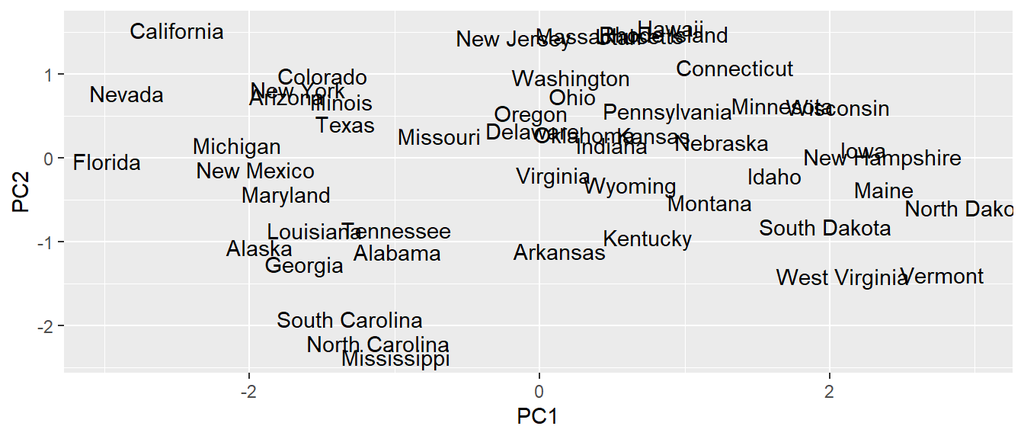

```r
scores <- as.data.frame(P$x)
scores$State <- rownames(P$x) ### row names were used to store states
ggplot(data = scores, aes(x = PC1, y = PC2, label = State)) + geom_text()
```

We can look at a few states to help us further understand the usefulness of PCA:

**Question 3**: Describe the states *South Carolina* and *Wisconsin* using the graph displayed above.

### Practice

The code below creates a subset of the “colleges2019” data set with no missing data in the variables that are selected:

```r
colleges <- read.csv("https://remiller1450.github.io/data/Colleges2019.csv")
cd <- colleges %>%
  select(Name, State, Enrollment, Adm_Rate, ACT_median,
         Net_Tuition, FourYearComp_Males, FourYearComp_Females,
        Debt_median, Salary10yr_median)
cd <- cd[complete.cases(cd),]  ## Keeps only complete cases (no missing values)
```

In the questions that follow you will progress through the basic steps of PCA:

**Question 4 (Part A)**: Create a new data frame where all the numeric variables are standardized. To do this you must remove the “Name” and “State” columns.

**Question 4 (Part B)**: Perform PCA using the `prcomp()` function. Then, considering only loadings above 0.4 in absolute value (a commonly used threshold), come up with a label for the *first* principal component.

**Question 4 (Part C)**: Considering only loadings above 0.4 in absolute value (a commonly used threshold), come up with a label for the *second* principal component.

**Question 4 (Part D)**: Using `geom_text()` create a graphic that displays the $PC_1$ and $PC_2$ scores of *all colleges in Iowa*. Briefly comment on the position of Grinnell College in this graph, mentioning why you think its location is so far from the other Iowa colleges.

$~$

### When to consider PCA?

Principal component analysis is useful when your data contain several numeric variables that are related with each other such that they might be measuring variation in the same underlying factor.

The first step in determining if PCA is viable is to look at the pairwise relationships between variables. The `corrplot` package provides several useful functions for this. Demonstrated below are a few of the package’s functions:

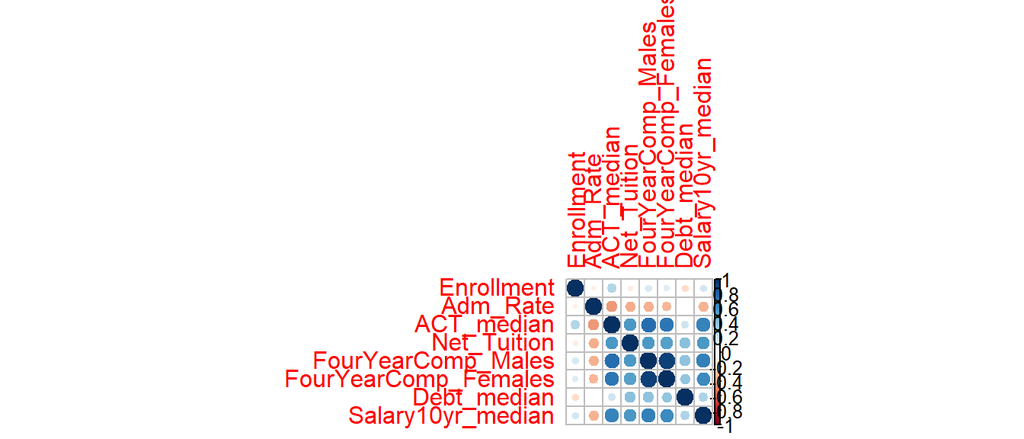

```r
## Create the correlation matrix (dropping identifiers)
cormat = cor(select(cd, -Name,-State))

## Default Corrplot
corrplot(cormat)
```

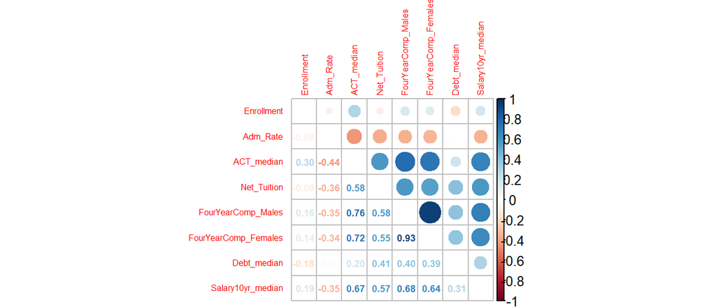

```r
## Mixed corrplot
corrplot.mixed(cormat, tl.pos = 'lt', tl.cex = 0.5, number.cex = 0.55)
```

In the second example, the argument `tl.pos` moves the text labels to the left and top, “tl”. You could also place them on the diagonal using “d”. The arguments `tl.cex` and `number.cex` change the size of the text labels and correlation coefficients (respectively).

$~$

### Variable Contributions

Principal components are linear combinations of the original variables. And if the data are standardized, a variable’s loading is a direct reflection of its importance.

The `fviz_contrib()` function provides a convenient way to visualize variable contributions:

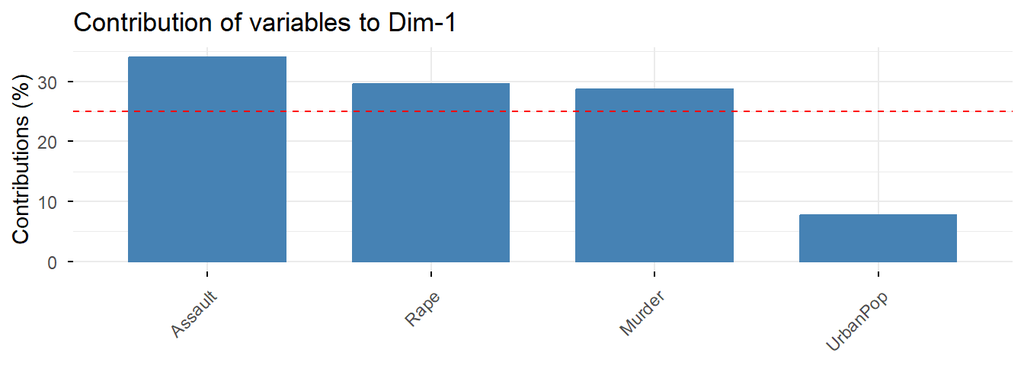

```r
P <- prcomp(USArrests_std)
fviz_contrib(P, choice = "var", axes = 1, top = 4)  ## PC1
```

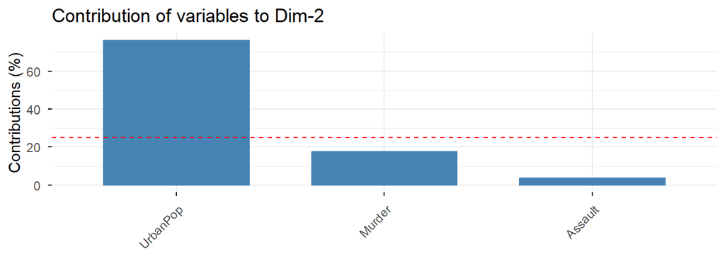

```r
fviz_contrib(P, choice = "var", axes = 2, top = 3)  ## PC2
```

The horizontal reference line shows the expected loading if each variable contributed uniformly to all of the principal components. Any variable whose loading is the above the reference line can be viewed as “important” in that dimension.

**Question 6**: Use `fviz_contrib()` to display the contributions of variables to the first principal component in the PCA of the “colleges” data you perform in Question 4. Do the variables that appear above the reference line correspond with the ones you mentioned in Part B of Question 4? Briefly explain.

$~$

### Explained Variation

Principal components are constructed so that earlier components explain more variability in the data than the later components. Thus, not all components are equally valuable - but how should we decide which to keep and interpret and which to discard?

Recall that the matrix $\mathbf{L}$ contains the eigenvalues of the covariance matrix. These values must sum to $p$ (the number of variables in the original data), so if we divide them by $p$ we get a measure of *variation explained* by a component.

Note that the `prcomp()` function will report the square root of the eigenvalues:

```r
P <- prcomp(USArrests_std)  ## US Arrests data
sum(P$sdev^2)               ## Recall there were 4 variables
```

```
## [1] 4
```

A popular graphic for visualizing explained variation is the **scree plot**:

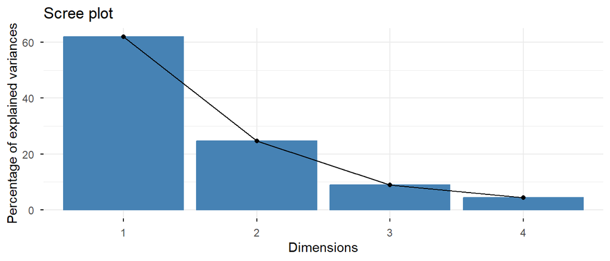

```r
fviz_screeplot(P)
```

The x-axis displays each principal component, while the y-axis displays the corresponding percentage of variance explained by that component. For the “USArrests” data, the first two principal components account for nearly 90% of variation across different states.

We can find the precise y-values of this graph ourselves by dividing the eigenvalues by $p$ (the number of columns of the original data):

```r
P$sdev^2/ncol(USArrests_std)
```

```
## [1] 0.62006039 0.24744129 0.08914080 0.04335752
```

**Question 7**: Construct a scree plot for the PCA you performed on the “colleges” data in Question 4. Next, use the PCA results to find the exact proportion of variation explained by the first three components (ie: calculate and sum the y-values displayed on your scree plot for $PC_1$, $PC_2$, and $PC_3$).

$~$

### Parallel Analysis

Depending on the goals of an analysis, you might subjectively choose to retain a certain number of principal components by inspecting the scree plot.

Alternatively, some suggest retaining all components that explain at least as much variation as a variable in the original data. This corresponds to an eigenvalue $\geq 1$ or explained variation $\geq 1/p$.

While popular, neither these methods are particularly rigorous. A more reliable way to determine the number of components to retain is **parallel analysis**.

Parallel analysis is a statistical approach that compares the eigenvalues of the real data to a distribution of those found in *randomly generated data of the same size* (think of a randomization test from Sta-209). We can perform parallel analysis using the `fa.parallel()` function in the `psych` library:

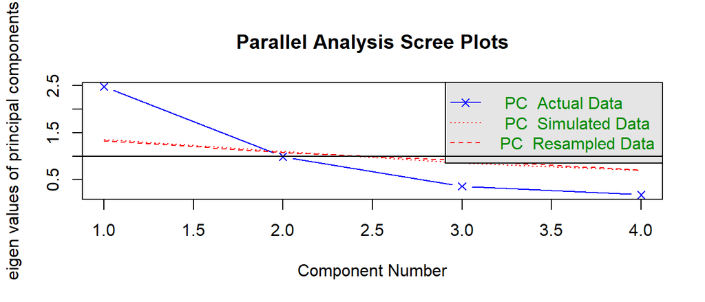

```
## Parallel analysis suggests that the number of factors =  NA  and the number of components =  1
```

```r
fa.parallel(USArrests_std, fa = "pc")  ## fa = "pc" indicates PCA
```

For the “USArrests” data, parallel analysis suggests we should only retain the first principal component (which we previously labeled “overall violent crime”).

**Question 8**: Perform parallel analysis on the “colleges” data that you’ve used in previous several questions. Report the number of components that the method suggests should be retained.

$~$

### Biplots

A **biplot** is a commonly used graph that combines the *scores* of individual observations and the *loadings* of the original variables on two of the principal component axes.

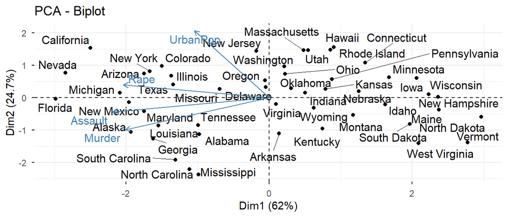

```r
fviz_pca_biplot(P, axes = c(1,2), repel = TRUE)  ## PC1 and PC2 for USArrests
```

Notice how the argument `repel = TRUE` can be used to prevent text labels from overlapping.

**Question 9:** Explain what we can learn from this graph. What extra information is provided compared to what we’ve seen before?